# Lab 09, Experiment 1

# Amplitude Shift Keying

```python
%matplotlib inline
from pylab import *
import filtfun as ff
from scipy.signal import butter, lfilter
import showfun as sf
import wavfun as wf
import amfun as am
import ascfun as af
```

# Part (a)

```python
# File: keyfun.py
# Functions for amplitude/frequency/phase shift keying
# ASK, FSK, PSK and hybrid APSK
from pylab import *
import pamfun
def askxmtr(anthcn,FB,Fs,ptype,pparms,xtype,fcparms):
    """
    Amplitude Shift Keying (ASK) Transmitter for
    Choherent ('coh') and Non-coherent ('noncoh') ASK Signals
    >>>>> tt,xt,st = askxmtr(anthcn,FB,Fs,ptype,pparms,xtype,fcparms) <<<<<
    where tt:time axis for x(t), starts at t=-TB/2
    xt:transmitted ASK signal, sampling rate Fs
    x(t) = s(t)*cos(2*pi*fc*t+(pi/180)*thetac)
    tt:time axis for x(t), starts at t=-TB/2
    st:baseband PAM signal s(t) for 'coh'
    st = sit + 1j*sqt for 'noncoh'
    sit:PAM signal of an*cos(pi/180*thetacn)
    sqt:PAM signal of an*sin(pi/180*thetacn)
    xtype:Transmitter type from list {'coh','noncoh'}
    anthcn = [an]    for {'coh'}
    anthcn = [[an],[thetacn]]  for {'noncoh'}
    an:N-symbol DT input sequence a_n, 0<=n<N
    thetacn: N-symbol DT sequence theta_c[n] in degrees,
    used instead of thetac for {'noncoh'} ASK
    FB:baud rate of a_n (and theta_c[n]), TB=1/FB
    Fs:sampling rate of x(t), s(t)
    ptype:pulse type from list ['man','rcf','rect','rrcf','sinc','tri']
    pparms = []  for {'man','rect','tri'}
    pparms = [k, alpha] for {'rcf','rrcf'}
    pparms = [k, beta]
    for {'sinc'}
    k:"tail" truncation parameter for {'rcf','rrcf','sinc'}
    (truncates at -k*TB and k*TB)
    alpha:Rolloff parameter for {'rcf','rrcf'}, 0<=alpha<=1
    beta:Kaiser window parameter for {'sinc'}
    fcparms = [fc, thetac] for {'coh'}
    fcparms = [fc] for {'noncoh'}
    fc:carrier frequency in Hz
    thetac: carrier phase in deg (0: cos, -90: sin)
    """
    xtype = xtype.lower()
    ptype = ptype.lower()
    if xtype == 'coh':
        an = anthcn
        fc=fcparms[0]
        tt, st = pamfun.pam12(an, FB, Fs, ptype, pparms=[])
        st[where(st<0)] = 0
        thetac = fcparms[1]
        xt = st*cos(2*pi*fc*tt + thetac)
    elif xtype == 'noncoh':
        an = anthcn[0]
        fc = fcparms
        thetacn = anthcn[1]
        tt, sit = pamfun.pam12(an*cos(thetacn), FB, Fs, ptype, pparms=[])
        tt, sqt = pamfun.pam12(an*sin(thetacn), FB, Fs, ptype, pparms=[])
        st = sit + 1j*sqt
        xt = real(st*exp(1j*2*pi*fc*tt))
    else:
        print("xtype is incorrect")

    return tt, xt, st
```

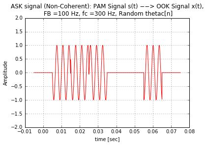

```python
# For testing noncoh transmission

an = array([0, 1, 1, 1, 0, 0, 1, 0])     # taking the same data seq as taken in Lab Manual Page(4)
thetacn = 2*pi*rand(len(an))
anthcn = [an, thetacn]
tt,xt,st = askxmtr(anthcn,FB=100,Fs=44100,ptype='rect',pparms=[],xtype='noncoh',fcparms=300)
plot(tt,xt, '-r')
xlabel("time [sec]")
ylabel("Amplitude")
title("ASK signal (Non-Coherent): PAM Signal s(t) −−> OOK Signal x(t),\n FB =100 Hz, fc =300 Hz, Random thetac[n]")
ylim([-2,2])
grid()
show()
```

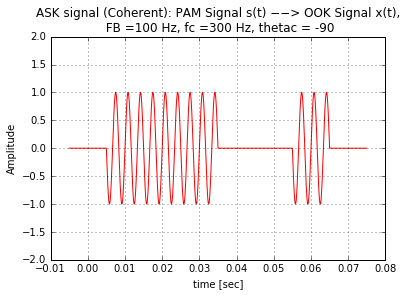

```python
# For testing coh transmission

#an = array(np.floor(randn(200)%2)%2, int8)
an = array([0, 1, 1, 1, 0, 0, 1, 0])                       # taking the same data seq as taken in Lab Manual Page(2)
anthcn = an
tt,xt,st = askxmtr(anthcn,FB=100,Fs=44100,ptype='rect',pparms=[],xtype='coh',fcparms=[300,-pi/2])
plot(tt,xt, '-r')
xlabel("time [sec]")
ylabel("Amplitude")
title("ASK signal (Coherent): PAM Signal s(t) −−> OOK Signal x(t),\n FB =100 Hz, fc =300 Hz, thetac = -90")
ylim([-2,2])
grid()
show()
```

# Part (b)

In the keyfun.py module, complete the following ASK receiver function, called askrcvr. The goal is to be able to use it to receive coherent and noncoherent ASK signals, and to make scatter plots. Use the pamrcvr10 function in module pamfun as part of the ASK receiver. Test askrcvr together with askxmtr using random (unipolar) binary data and the parameters given in part (a).

```python
# File: keyfun.py
# Functions for amplitude/frequency/phase shift keying
# ASK, FSK, PSK and hybrid APSK
from pylab import *
import pamfun
def askrcvr(tt,rt,rtype,fcparms,FBparms,ptype,pparms):
    """
    Amplitude Shift Keying (ASK) Receiver for
    Coherent ('coh') and Non-coherent ('noncoh') ASK Signals
    >>>>> bn,bt,wt,ixn = askrcvr(tt,rt,rtype,fcparms,FBparms,ptype,pparms) <<<<<
    where bn:received DT sequence b[n]
    bt:received 'CT' PAM signal b(t)
    wt = wit + 1j*wqt
    wit:in-phase component of b(t)
    wqt:quadrature component of b(t)
    ixn:sampling time indexes for b(t)->b[n], w(t)->w[n]
    tt:time axis for r(t)
    rt:received (noisy) ASK signal r(t)
    rtype:receiver type from list ['coh','noncoh']
    fcparms = [fc, thetac] for {'coh'}
    fcparms = [fc] for {'noncoh'}
    fc:carrier frequency in Hz
    thetac:carrier phase in deg (0: cos, -90: sin)
    FBparms = [FB, dly]
    FB:baud rate of PAM signal, TB=1/FB
    dly:sampling delay for b(t)->b[n], fraction of TB
    sampling times are t=n*TB+t0 where t0=dly*TB
    ptype:pulse type from list ['man','rcf','rect','rrcf','sinc','tri']
    pparms = [] for 'man','rect','tri'
    pparms = [k, alpha] for {'rcf','rrcf'}
    pparms = [k, beta] for {'sinc'}
    k:"tail" truncation parameter for {'rcf','rrcf','sinc'}
    (truncates at -k*TB and k*TB)
    alpha:Rolloff parameter for {'rcf','rrcf'}, 0<=alpha<=1
    beta:Kaiser window parameter for {'sinc'}
    """
    ptype = ptype.lower()
    rtype = rtype.lower()
    Fs = int(len(tt)/(tt[-1]-tt[0]))
    FBparms = FBparms
    pparms = pparms
    if rtype == 'coh':
        fc=fcparms[0]
        thetac = fcparms[1]
        rt = 2*rt*cos(2*pi*fc*tt + thetac)
        bn, bt, ixn = pamfun.pamrcvr10(tt, rt, FBparms, ptype, pparms)
        wt = bt
        bn[where(bn>0.0001)] = 1
        bn[where(bn<=0.0001)] = 0
    elif rtype == 'noncoh':
        an = anthcn[0]
        fc = fcparms
        thetacn = anthcn[1]
        vt = 2*rt*exp(-1j*2*pi*fc*tt)
        bni, wit, ixni, = pamfun.pamrcvr10(tt, real(vt), FBparms, ptype, pparms)
        bnq, wqt, ixnq, = pamfun.pamrcvr10(tt, imag(vt), FBparms, ptype, pparms)
        bt = (wit**2 + wqt**2)**0.5
        N = ceil(FBparms[0]*(tt[-1]-tt[0]))
        ixn = array(around((arange(N)+0.5+FBparms[1])*Fs/FBparms[0]),int)
        bn = bt[ixn]
        bn[where(bn>0.01)] = 1
        bn[where(bn<=0.01)] = 0
        wt = wit + 1j*wqt
    else:
        print("xtype is incorrect")
    bn = array(bn,int8)
    return bn, bt, wt, ixn
```

```python
# For testing coherent demodulator

an = array([0, 1, 1, 1, 0, 0, 1, 0])     # taking the same data seq as taken in Lab Manual Page(4)
anthcn = an
tt,xt,st = askxmtr(anthcn,FB=100,Fs=44100,ptype='rect',pparms=[],xtype='coh',fcparms=[300,-pi/2])

bn, bt, wt, ixn=askrcvr(tt,xt,rtype='coh',fcparms=[300,-pi/2],FBparms=[100,0],ptype='rect',pparms=[])
```

```python
bn
```

```
array([0, 1, 1, 1, 0, 0, 1, 0], dtype=int8)
```

```python
# to count the difference between initial sequence and the sequence received

list(an-bn).count(1)
```

```
0
```

**Our coherent demodulator is working fine.**

```python
# For testing non-coherent demodulator

an = array([0, 1, 1, 1, 0, 0, 1, 0])     # taking the same data seq as taken in Lab Manual Page(4)
thetacn = 2*pi*rand(len(an))
anthcn = [an,thetacn]
tt,xt,st = askxmtr(anthcn,FB=100,Fs=44100,ptype='rect',pparms=[],xtype='noncoh',fcparms=300)

bn, bt, wt, ixn=askrcvr(tt,xt,rtype='noncoh',fcparms=300,FBparms=[100,0],ptype='rect',pparms=[])
```

```python
bn
```

```
array([0, 1, 1, 1, 0, 0, 1, 0], dtype=int8)
```

```python
# to count the difference between initial sequence and the sequence received

list(an-bn).count(1)
```

```
0
```

```python
# For testing non-coherent demodulator using random sequence

an = array(np.floor(randn(200)%2)%2, int8)
thetacn = 2*pi*rand(len(an))
anthcn = [an,thetacn]
tt,xt,st = askxmtr(anthcn,FB=100,Fs=44100,ptype='rect',pparms=[],xtype='noncoh',fcparms=300)

bn, bt, wt, ixn=askrcvr(tt,xt,rtype='noncoh',fcparms=300,FBparms=[100,0],ptype='rect',pparms=[])
```

```python
bn
```

```
array([0, 0, 1, 1, 0, 1, 1, 0, 0, 1, 0, 0, 0, 0, 0, 1, 0, 1, 0, 0, 1, 1, 0,
       0, 0, 0, 1, 0, 0, 1, 1, 1, 0, 0, 0, 1, 0, 0, 1, 1, 1, 1, 0, 0, 1, 0,
       0, 0, 0, 0, 0, 1, 1, 1, 1, 0, 0, 1, 0, 1, 1, 0, 1, 0, 0, 1, 0, 0, 0,
       1, 1, 0, 0, 0, 1, 1, 0, 0, 1, 0, 0, 0, 0, 1, 1, 1, 0, 0, 1, 1, 0, 0,
       1, 1, 1, 0, 0, 1, 0, 1, 0, 1, 0, 0, 1, 0, 1, 1, 1, 1, 0, 0, 0, 0, 1,
       0, 1, 0, 1, 0, 0, 1, 1, 0, 1, 0, 1, 1, 0, 1, 1, 1, 0, 1, 1, 0, 1, 0,
       1, 0, 1, 1, 1, 0, 1, 1, 0, 0, 1, 1, 0, 1, 1, 0, 0, 0, 0, 1, 1, 0, 1,
       1, 1, 1, 0, 0, 1, 0, 1, 0, 1, 0, 0, 0, 1, 1, 0, 1, 1, 0, 0, 0, 0, 0,
       0, 0, 1, 0, 0, 0, 1, 0, 1, 1, 0, 1, 0, 0, 1, 0], dtype=int8)
```

```python
an
```

```
array([0, 0, 1, 1, 0, 1, 1, 0, 0, 1, 0, 0, 0, 0, 0, 1, 0, 1, 0, 0, 1, 1, 0,
       0, 0, 0, 1, 0, 0, 1, 1, 1, 0, 0, 0, 1, 0, 0, 1, 1, 1, 1, 0, 0, 1, 0,
       0, 0, 0, 0, 0, 1, 1, 1, 1, 0, 0, 1, 0, 1, 1, 0, 1, 0, 0, 1, 0, 0, 0,
       1, 1, 0, 0, 0, 1, 1, 0, 0, 1, 0, 0, 0, 0, 1, 1, 1, 0, 0, 1, 1, 0, 0,
       1, 1, 1, 0, 0, 1, 0, 1, 0, 1, 0, 0, 1, 0, 1, 1, 1, 1, 0, 0, 0, 0, 1,
       0, 1, 0, 1, 0, 0, 1, 1, 0, 1, 0, 1, 1, 0, 1, 1, 1, 0, 1, 1, 0, 1, 0,
       1, 0, 1, 1, 1, 0, 1, 1, 0, 0, 1, 1, 0, 1, 1, 0, 0, 0, 0, 1, 1, 0, 1,
       1, 1, 1, 0, 0, 1, 0, 1, 0, 1, 0, 0, 0, 1, 1, 0, 1, 1, 0, 0, 0, 0, 0,
       0, 0, 1, 0, 0, 0, 1, 0, 1, 1, 0, 1, 0, 0, 1, 0], dtype=int8)
```

```python
# to count the difference between initial sequence and the sequence received

list(an-bn).count(1)
```

```
0
```

**We can see that bn is the same sequence which we modulated (non-coherent). Our non-coherent demodulator is working fine.**

# Part (c)

Let Fs = 44100 Hz, FB = 100 baud, fc = 2100 Hz, and let p(t) be a rectangular pulse of width TB. Use random binary data to produce (i) a coherent OOK signal, (ii) a noncoherent OOK signal, and (iii) a BPSK signal, each of duration 2 sec. Plot and compare the PSDs for all three cases. Then use the wt and wn=wt[ixn] outputs of the askrcvr function to make scatter plots for the three signals and compare them. Are there any interesting spectral lines if you look at the PSDs of the squared ASK signals? How do things change if you use a triangular pulse p(t) (of total width 2TB from −TB to +TB) instead of the rectangular pulse?

```python
Fs = 44100
FB = 100
fc = 2100
tlen = 2
nsamples = tlen*Fs
nbits = tlen*FB
an = floor(2*(rand(nbits)))
```

**(i) a coherent OOK signal**

```python
anthcn = an
tt,xt,st = askxmtr(anthcn,FB,Fs,ptype='rect',pparms=[],xtype='coh',fcparms=[fc,-pi/2])
```

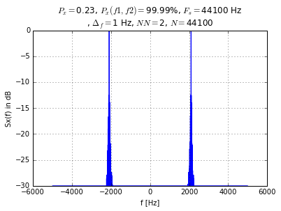

```python
sf.showpsd(xt, Fs, [-5000,5000,-30], Fs)
```

```python
bn, bt, wt, ixn=askrcvr(tt,xt,rtype='coh',fcparms=[fc,0],FBparms=[FB,0],ptype='rect',pparms=[])
```

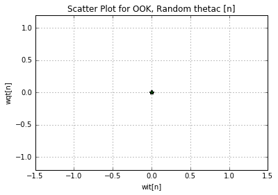

```python
plot(wt[ixn].real, wt.imag[ixn], 'g*')
title("Scatter Plot for OOK, Random thetac [n]")
xlabel('wit[n]')
ylabel('wqt[n]')
xlim([-1.5,1.5])
ylim([-1.2,1.2])
grid()
show()
```

**Now, Squaring the signal**

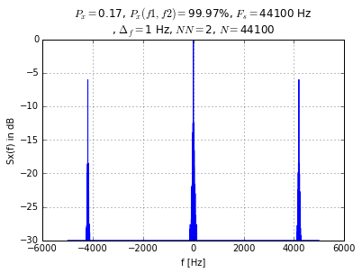

```python
sf.showpsd(xt**2, Fs, [-5000,5000,-30], Fs)
```

**The PSD of the squared signal has a sharp line at double the career frequency and also has DC component because of the net DC component.**

**(ii) a non-coherent OOK signal**

```python
thetacn = 2*pi*rand(len(an))
anthcn = [an,thetacn]
tt,xt,st = askxmtr(anthcn,FB,Fs,ptype='rect',pparms=[],xtype='noncoh',fcparms=fc)
```

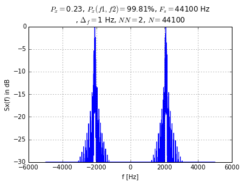

```python
sf.showpsd(xt, Fs, [-5000,5000,-30], Fs)
```

```python
bn, bt, wt, ixn=askrcvr(tt,xt,rtype='noncoh',fcparms=fc,FBparms=[FB,0],ptype='rect',pparms=[])
```

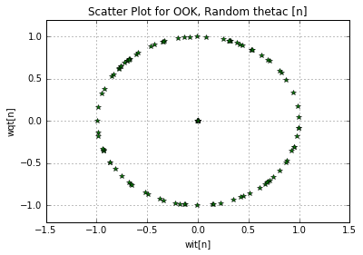

```python
plot(wt[ixn].real, wt.imag[ixn], 'g*')
title("Scatter Plot for OOK, Random thetac [n]")
xlabel('wit[n]')
ylabel('wqt[n]')
xlim([-1.5,1.5])
ylim([-1.2,1.2])
grid()
show()
```

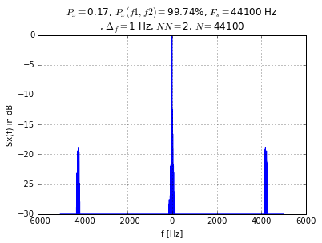

```python
sf.showpsd(xt**2, Fs, [-5000,5000,-30], Fs)
```

**The PSD of the squared signal has a blunt peak at double the career frequency and also has DC component because of the net DC component.**

**(iii) a BPSK signal**

```python
anthcn = 2*an - 1
tt,xt,st = askxmtr(anthcn,FB,Fs,ptype='rect',pparms=[],xtype='coh',fcparms=[fc,-pi/2])
```

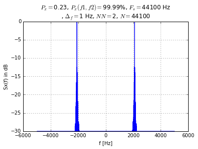

```python
sf.showpsd(xt, Fs, [-5000,5000,-30], Fs)
```

```python
bn, bt, wt, ixn=askrcvr(tt,xt,rtype='coh',fcparms=[fc,0],FBparms=[FB,0],ptype='rect',pparms=[])
```

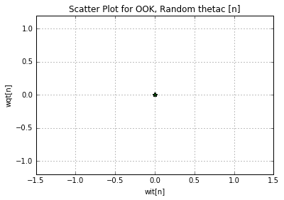

```python
plot(wt[ixn].real, wt.imag[ixn], 'g*')
title("Scatter Plot for OOK, Random thetac [n]")
xlabel('wit[n]')
ylabel('wqt[n]')
xlim([-1.5,1.5])
ylim([-1.2,1.2])
grid()
show()
```

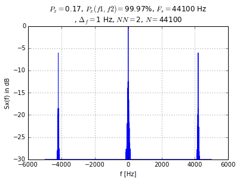

```python
sf.showpsd(xt**2, Fs, [-5000,5000,-30], Fs)
```

**The PSD of the squared signal has a sharp peak at double the career frequency and also has DC component because of the net DC component.**

# Part (d)

The wav files asksig901.wav, asksig902.wav and asksig903.wav are binary ASK signals which contain 8-bit, LSB-first, ASCII signals. Analyze the three signals and extract the text messages.

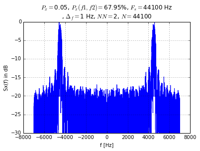

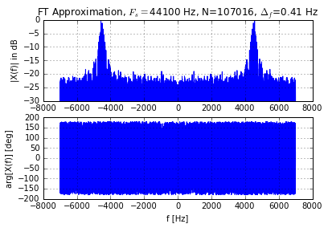

```python
rt, Fs = wf.wavread('asksig901.wav')
tt = arange(0,len(rt))/Fs
sf.showpsd(rt, Fs, [-7000,7000,-30], Fs)
sf.showft(tt,rt,[-7000,7000, -30])
```

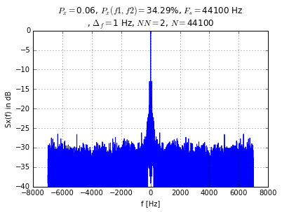

```python
fc = 4580
yt = 2*rt*cos(2*pi*fc*tt)
sf.showpsd(yt**4, Fs, [-7000,7000,-40], Fs)
```

**From the above plot, we found fc = 4580.**

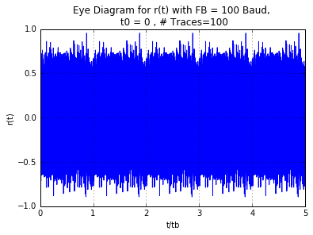

```python
sf.showeye(rt, Fs, FB=100, NTd=100, dispparms=[0, 5, -1, 1])
```

```python
bn, bt, wt, ixn=askrcvr(tt,rt,rtype='noncoh',fcparms=fc,FBparms=[FB,0],ptype='rect',pparms=[])
```

```python
bn=bn[0:len(bn)-len(bn)%8]
```